# Group1_finalprojectRmd

# Load Packages

```r
library(tidyverse)
library(readxl)
library(broom)
library(cowplot)
library(phyloseq)
library(vegan)
set.seed(7)
```

#Import Data

```r
library(readr)
biographical <- read_delim("~/Group1_Bio201_FinalProject/raw_data/biographical.txt",
    "\t", escape_double = FALSE, trim_ws = TRUE)
View(biographical)

library(readr)
phylum_avg_shared <- read_delim("~/Group1_Bio201_FinalProject/raw_data/phylum_avg_shared.txt",
    "\t", escape_double = FALSE, trim_ws = TRUE)
View(phylum_avg_shared)

library(readr)
all_data_wkly <- read_delim("~/Group1_Bio201_FinalProject/raw_data/Bigzipfile/all_data_wkly.txt",
    "\t", escape_double = FALSE, trim_ws = TRUE)
View(all_data_wkly)
```

#Tidy Data ##Butyrate and Propionate df

```r
c_all_data_wkly <- all_data_wkly %>%
  rename_all(tolower) %>%
  select(participant_id, semester, supplement_consumed, frequency, quantity_compliant, study_week, butyrate_mean, propionate_mean) %>% #keep only columns of interest
  filter(study_week == "week1" | study_week == "week3", quantity_compliant == "yes") #curated all data weekly: keep only weeks and supplements of interest

#wide dfs
but_wide <- all_data_wkly %>%
  rename_all(tolower) %>%
  select(participant_id, semester, supplement_consumed, frequency, quantity_compliant, study_week, butyrate_mean) %>% #keep only columns of interest
  filter(study_week == "week1" | study_week == "week3", quantity_compliant == "yes") %>% #keep only weeks of interest, quantity compliant, and 1x
  spread(study_week, butyrate_mean) %>%
  mutate(delta_butyrate = week3 - week1) #calculate difference in butyrate

pro_wide <- all_data_wkly %>%
  rename_all(tolower) %>%
  select(participant_id, semester, supplement_consumed, frequency, quantity_compliant, study_week, propionate_mean) %>% #keep only columns of interest
  filter(study_week == "week1" | study_week == "week3", quantity_compliant == "yes") %>% #keep only weeks of interest, quantity compliant, and 1x
  spread(study_week, propionate_mean) %>%
  mutate(delta_propionate = week3 - week1) #calculate difference in propionate

but_pro_wide <- inner_join(x = but_wide, y = pro_wide,
                    by = c("participant_id",
                           "semester", "supplement_consumed", "frequency")) %>%
  rename(but_wk1 = week1.x, but_wk3 = week3.x, pro_wk1 = week1.y, pro_wk3 = week3.y) %>%
  select(-starts_with("quantity_compliant")) #all measurements by participant ID

#Save Data Frames:
write_delim(c_all_data_wkly, path = "curated_data/c_all_data_wkly.txt",
            delim = "\t", col_names = TRUE, quote = FALSE)
write_delim(but_wide, path = "curated_data/but_wide.txt",
            delim = "\t", col_names = TRUE, quote = FALSE)
write_delim(pro_wide, path = "curated_data/pro_wide.txt",
            delim = "\t", col_names = TRUE, quote = FALSE)
write_delim(but_pro_wide, path = "curated_data/but_pro_wide.txt",
            delim = "\t", col_names = TRUE, quote = FALSE)
```

##BMI df

```r
BMI_data <- biographical %>%
  rename_all(tolower) %>%
  select(participant_id, sex, age, race_ethnicity, weight_kg, height_meters) %>%
  drop_na(weight_kg, height_meters) %>%
  mutate(BMI = weight_kg/(height_meters)^2) #calculate all BMIs; n = 252

underweight_BMI <- BMI_data %>%
  filter(BMI < 18.5) #subset by CDC category: underweight - n = 12

healthy_BMI <- BMI_data %>%
  filter(BMI >= 18.5, BMI < 25) #subset by CDC category: healthy - n = 186

overweight_BMI <- BMI_data %>%
  filter(BMI >= 25, BMI < 30) #subset by CDC category: overweight - n = 39

obese_BMI <- BMI_data %>%
  filter(BMI >= 30) #subset by CDC category: obese - n = 15

#total n = 252

#Save Data Frames
write_delim(BMI_data, path = "curated_data/BMI_data.txt",
            delim = "\t", col_names = TRUE, quote = FALSE)
write_delim(underweight_BMI, path = "curated_data/underweight_BMI.txt",
            delim = "\t", col_names = TRUE, quote = FALSE)
write_delim(healthy_BMI, path = "curated_data/healthy_BMI.txt",
            delim = "\t", col_names = TRUE, quote = FALSE)
write_delim(overweight_BMI, path = "curated_data/overweight_BMI.txt",
            delim = "\t", col_names = TRUE, quote = FALSE)
write_delim(obese_BMI, path = "curated_data/obese_BMI.txt",
            delim = "\t", col_names = TRUE, quote = FALSE)
```

##Phylum df

```r
#Creating Processed Phylum Data Frame:
phylum_processed_df <- phylum_avg_shared %>%
  rename_all(tolower) %>%
  filter(study_week == "week1" | study_week == "week3") %>%
  select("participant_id", "semester", "study_week", "firmicutes", "bacteroidetes <bacteroidetes>") %>%
  rename(., "bacteroidetes" = "bacteroidetes <bacteroidetes>") %>%
  mutate(., f_b_ratio = firmicutes/bacteroidetes)

#Checking Sample Sizes for Consistency by Week:
phylum_processed_df %>%
  filter(study_week == "week1") %>%
  summarise(sample_size = n()) # n = 508
```

```
## # A tibble: 1 x 1
##   sample_size
##         <int>
## 1         508
```

```r
phylum_processed_df %>%
  filter(study_week == "week3") %>%
  summarise(sample_size = n()) # n = 480. 508-480 = 28 inconsistencies.
```

```
## # A tibble: 1 x 1
##   sample_size
##         <int>
## 1         480
```

```r
#Split by Weeks and Recombine so only samples with both weeks present:
phylum_week1 <- phylum_processed_df %>%
  filter(study_week == "week1")

phylum_week3 <- phylum_processed_df %>%
  filter(study_week == "week3")
phylum_week3
```

```
## # A tibble: 480 x 6
##    participant_id semester study_week firmicutes bacteroidetes f_b_ratio
##    <chr>          <chr>    <chr>           <dbl>         <dbl>     <dbl>
##  1 U042           Fall2015 week3          13515         16756      0.807
##  2 U044           Fall2015 week3          15632          7587      2.06
##  3 U046           Fall2015 week3           7980.        17707      0.451
##  4 U048           Fall2015 week3          12427         22233      0.559
##  5 U050           Fall2015 week3          12079          9706      1.24
##  6 U052           Fall2015 week3           5324         16858      0.316
##  7 U054           Fall2015 week3          12668.        14542.     0.871
##  8 U057           Fall2015 week3           8265         16255      0.508
##  9 U059           Fall2015 week3           8742         14673      0.596
## 10 U062           Fall2015 week3           6117.        21792.     0.281
## # ... with 470 more rows
```

```r
phylum_processed_df_both_weeks_present <- inner_join(phylum_week1, phylum_week3, by = (c("participant_id")))

#Final Data Frames:
phylum_processed_df
```

```
## # A tibble: 988 x 6
##    participant_id semester study_week firmicutes bacteroidetes f_b_ratio
##    <chr>          <chr>    <chr>           <dbl>         <dbl>     <dbl>
##  1 U042           Fall2015 week1          14119          18149     0.778
##  2 U042           Fall2015 week3          13515          16756     0.807
##  3 U044           Fall2015 week3          15632           7587     2.06
##  4 U046           Fall2015 week3           7980.         17707     0.451
##  5 U048           Fall2015 week3          12427          22233     0.559
##  6 U050           Fall2015 week3          12079           9706     1.24
##  7 U051           Fall2015 week1          19352           4827     4.01
##  8 U052           Fall2015 week1           4944          13166     0.376
##  9 U052           Fall2015 week3           5324          16858     0.316
## 10 U053           Fall2015 week1           7061          22655     0.312
## # ... with 978 more rows
```

```r
phylum_processed_df_both_weeks_present
```

```
## # A tibble: 451 x 11
##    participant_id semester.x study_week.x firmicutes.x bacteroidetes.x
##    <chr>          <chr>      <chr>               <dbl>           <dbl>
##  1 U042           Fall2015   week1              14119           18149
##  2 U052           Fall2015   week1               4944           13166
##  3 U054           Fall2015   week1              11479           20357
##  4 U062           Fall2015   week1               8366           25134.
##  5 U063           Fall2015   week1              16913.          10266
##  6 U064           Fall2015   week1              10583           10990
##  7 U066           Fall2015   week1               9209           14273
##  8 U067           Fall2015   week1              19163.          16210.
##  9 U068           Fall2015   week1               6034           20364
## 10 U070           Fall2015   week1              11963           13446
## # ... with 441 more rows, and 6 more variables: f_b_ratio.x <dbl>,
## #   semester.y <chr>, study_week.y <chr>, firmicutes.y <dbl>,
## #   bacteroidetes.y <dbl>, f_b_ratio.y <dbl>
```

```r
phylum_processed_df_both_weeks_present_final <- phylum_processed_df_both_weeks_present %>%
  rename(firmicutes_wk1 = firmicutes.x, bacteroidetes_wk1 = bacteroidetes.x, fb_ratio_wk1 =
  f_b_ratio.x, firmicutes_wk3 = firmicutes.y, bacteroidetes_wk3 = bacteroidetes.y, fb_ratio_wk3 =
  f_b_ratio.y, semester = semester.x) %>%
  select(-starts_with("study_week"), -starts_with("semester.y"))
View(phylum_processed_df_both_weeks_present_final)

#Save data frames:
write_delim(phylum_processed_df, path = "curated_data/phylum_processed_df.txt",
            delim = "\t", col_names = TRUE, quote = FALSE)
write_delim(phylum_processed_df_both_weeks_present, path = "curated_data/phylum_processed_df_both_weeks_present.txt",
            delim = "\t", col_names = TRUE, quote = FALSE)
write_delim(phylum_processed_df_both_weeks_present_final, path = "curated_data/phylum_processed_df_both_weeks_present_final.txt",
            delim = "\t", col_names = TRUE, quote = FALSE)
```

##Joined BMI and scfas

```r
BMI_but_pro <- inner_join(x = BMI_data, y = but_pro_wide,
                          by = c("participant_id")) #n = 178

underweight_but_pro <- inner_join(x= underweight_BMI, y = but_pro_wide,
                                  by = c("participant_id")) #n = 10

healthy_but_pro <- inner_join(x= healthy_BMI, y = but_pro_wide,
                                  by = c("participant_id")) #n = 133

overweight_but_pro <-  inner_join(x= overweight_BMI, y = but_pro_wide,
                                  by = c("participant_id")) #n = 25

obese_but_pro <-  inner_join(x= obese_BMI, y = but_pro_wide,
                                  by = c("participant_id")) #n = 10
#total n = 178

#Save Data Frames
write_delim(BMI_but_pro, path = "curated_data/BMI_but_pro.txt",
            delim = "\t", col_names = TRUE, quote = FALSE)
write_delim(underweight_but_pro, path = "curated_data/underweight_but_pro.txt",
            delim = "\t", col_names = TRUE, quote = FALSE)
write_delim(healthy_but_pro, path = "curated_data/healthy_but_pro.txt",
            delim = "\t", col_names = TRUE, quote = FALSE)
write_delim(overweight_but_pro, path = "curated_data/overweight_but_pro.txt",
            delim = "\t", col_names = TRUE, quote = FALSE)
write_delim(obese_but_pro, path = "curated_data/obese_but_pro.txt",
            delim = "\t", col_names = TRUE, quote = FALSE)
```

##Joined BMI, scfas, and phylums

```r
BMI_phylum_scfa <- inner_join(x = BMI_but_pro, y = phylum_processed_df_both_weeks_present_final,
                          by = c("participant_id")) #n = 139

underweight_phylum_scfa  <- inner_join(x = underweight_but_pro, y = phylum_processed_df_both_weeks_present_final,
                          by = c("participant_id")) #n = 9

healthy_phylum_scfa <- inner_join(x = healthy_but_pro, y = phylum_processed_df_both_weeks_present_final,
                          by = c("participant_id")) #n = 105

overweight_phylum_scfa <- inner_join(x = overweight_but_pro, y = phylum_processed_df_both_weeks_present_final,
                          by = c("participant_id")) #n = 20

obese_phylum_scfa <- inner_join(x = obese_but_pro, y = phylum_processed_df_both_weeks_present_final,
                          by = c("participant_id")) #n = 5

#Save Data Frames
write_delim(BMI_phylum_scfa, path = "curated_data/BMI_phylum_scfa.txt",
            delim = "\t", col_names = TRUE, quote = FALSE)
write_delim(underweight_phylum_scfa, path = "curated_data/underweight_phylum_scfa.txt",
            delim = "\t", col_names = TRUE, quote = FALSE)
write_delim(healthy_phylum_scfa, path = "curated_data/healthy_phylum_scfa.txt",
            delim = "\t", col_names = TRUE, quote = FALSE)
write_delim(overweight_phylum_scfa, path = "curated_data/overweight_phylum_scfa.txt",
            delim = "\t", col_names = TRUE, quote = FALSE)
write_delim(obese_phylum_scfa, path = "curated_data/obese_phylum_scfa.txt",
            delim = "\t", col_names = TRUE, quote = FALSE)
```

#Analysis ##Broad (All BMIs) ###F:B and BMI

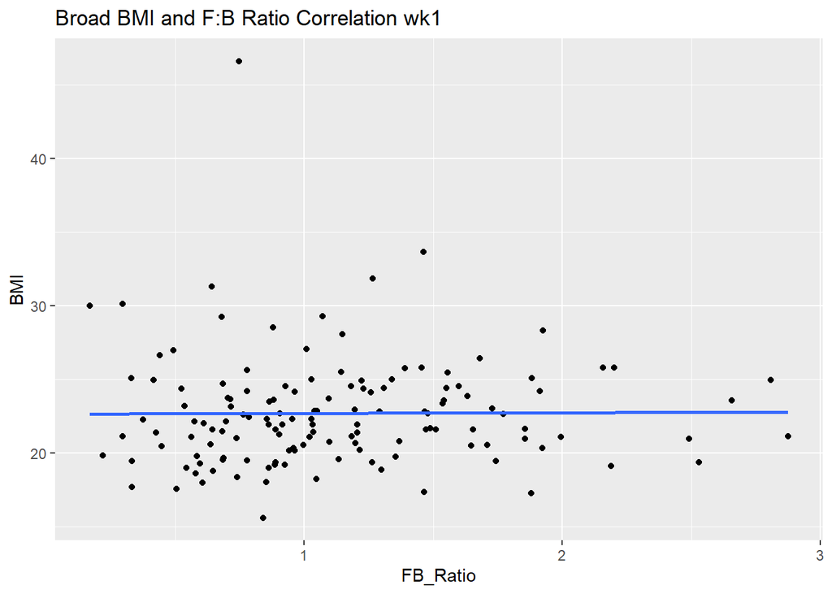

```r
lm_Broad_BMI_plot_wk1<-BMI_phylum_scfa %>%
  ggplot(aes(x = fb_ratio_wk1,
             y = BMI)) +
  geom_point() + #puts data points to match x and y coordinates
  geom_smooth(method = "lm", #used to create a linear best fit line
              se = FALSE) + #hides confidence interval around line
  xlab("FB_Ratio") +
  ylab("BMI") + labs(title = "Broad BMI and F:B Ratio Correlation wk1")
print(lm_Broad_BMI_plot_wk1)
```

```r
lm_Broad_BMI_wk1<-BMI_phylum_scfa %>%
  lm(fb_ratio_wk1 ~ BMI, data = .) #test relationship
summary(lm_Broad_BMI_wk1)
```

```
##
## Call:
## lm(formula = fb_ratio_wk1 ~ BMI, data = .)
##
## Residuals:
##      Min       1Q   Median       3Q      Max
## -0.95021 -0.40410 -0.09109  0.34665  1.76222
##
## Coefficients:
##              Estimate Std. Error t value Pr(>|t|)
## (Intercept) 1.0918175  0.2875401   3.797 0.000219 ***
## BMI         0.0009424  0.0124923   0.075 0.939977
## ---
## Signif. codes:  0 '***' 0.001 '**' 0.01 '*' 0.05 '.' 0.1 ' ' 1
##
## Residual standard error: 0.5505 on 137 degrees of freedom
## Multiple R-squared:  4.154e-05,  Adjusted R-squared:  -0.007257
## F-statistic: 0.005691 on 1 and 137 DF,  p-value: 0.94
```

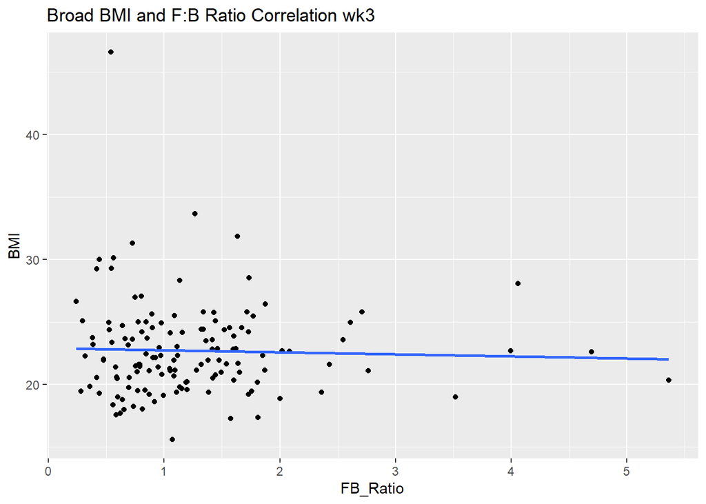

```r
lm_Broad_BMI_plot_wk3<-BMI_phylum_scfa %>%
  ggplot(aes(x = fb_ratio_wk3,
             y = BMI)) +
  geom_point() + #puts data points to match x and y coordinates
  geom_smooth(method = "lm", #used to create a linear best fit line
              se = FALSE) + #hides confidence interval around line
  xlab("FB_Ratio") +
  ylab("BMI")  + labs(title = "Broad BMI and F:B Ratio Correlation wk3")
print(lm_Broad_BMI_plot_wk3)
```

```r
lm_Broad_wk3_BMI<-BMI_phylum_scfa %>%
  lm(fb_ratio_wk3 ~ BMI, data = .) #test relationship
summary(lm_Broad_wk3_BMI)
```

```
##
## Call:
## lm(formula = fb_ratio_wk3 ~ BMI, data = .)
##
## Residuals:
##     Min      1Q  Median      3Q     Max
## -0.9814 -0.4982 -0.1734  0.2963  4.1048
##
## Coefficients:
##              Estimate Std. Error t value Pr(>|t|)
## (Intercept)  1.412211   0.426001   3.315  0.00117 **
## BMI         -0.007715   0.018508  -0.417  0.67745
## ---
## Signif. codes:  0 '***' 0.001 '**' 0.01 '*' 0.05 '.' 0.1 ' ' 1
##
## Residual standard error: 0.8157 on 137 degrees of freedom
## Multiple R-squared:  0.001267,   Adjusted R-squared:  -0.006023
## F-statistic: 0.1737 on 1 and 137 DF,  p-value: 0.6775
```

```r
save_plot(filename = "figures/lm_Broad_BMI_plot_wk1.pdf",
          plot = lm_Broad_BMI_plot_wk1,
          nrow = 1, ncol = 1,
          base_aspect_ratio = 2.1)

save_plot(filename = "figures/lm_Broad_BMI_plot_wk3.pdf",
          plot = lm_Broad_BMI_plot_wk3,
          nrow = 1, ncol = 1,
          base_aspect_ratio = 2.1)
```

The p-value for the linear correlation of the week 1 firmicutes to bacteroidetes ratio and the BMI of all the participants is .94, which is not statistically significant. The R^2 value was also insignificant being very small at R^2=-.0073. There is no significant correlation between the week 1 firmicutes - bacteroidetes ratio and BMI.

Similarly, the week 3 F - B ratio and BMI also had an insignifcant p-value and R^2 value at p=.67 and R^2 = -.006 respectively. This also represents no significant correlation.

###F:B and Butyrate

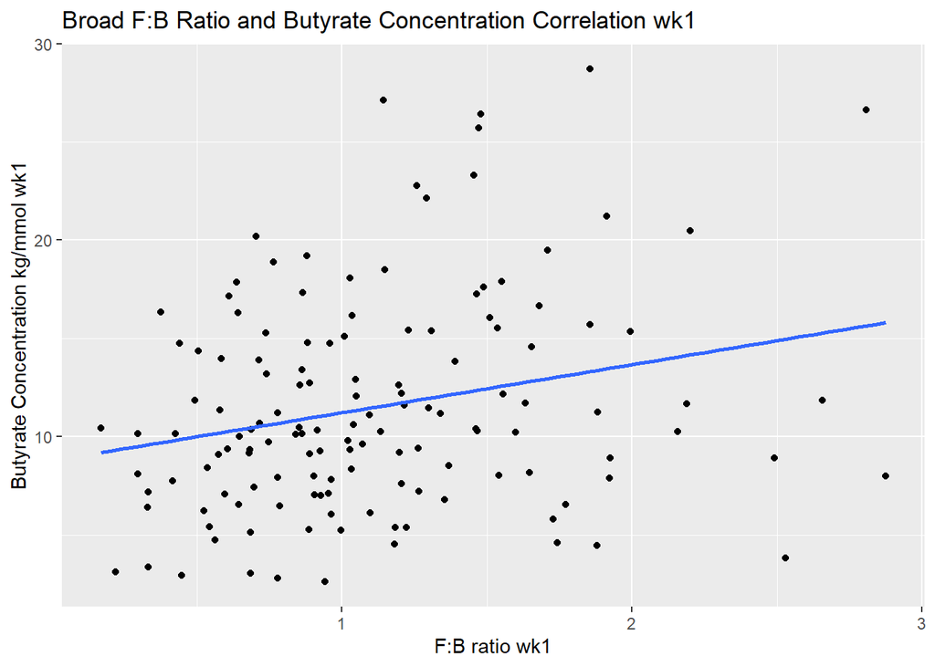

```r
lm_wk1_but_Broad_plot<-BMI_phylum_scfa %>%
  ggplot(aes(x = fb_ratio_wk1,
             y = but_wk1)) +
  geom_point() + #puts data points to match x and y coordinates
  geom_smooth(method = "lm", #used to create a linear best fit line
              se = FALSE) + #hides confidence interval around line
  xlab("F:B ratio wk1") +
  ylab("Butyrate Concentration kg/mmol wk1")  + labs(title = "Broad F:B Ratio and Butyrate Concentration Correlation wk1")
print(lm_wk1_but_Broad_plot)
```

```r
lm_wk1_but_Broad<-BMI_phylum_scfa %>%
  lm(fb_ratio_wk1 ~ but_wk1, data = .) #test relationship
summary(lm_wk1_but_Broad)
```

```
##
## Call:
## lm(formula = fb_ratio_wk1 ~ but_wk1, data = .)
##
## Residuals:
##      Min       1Q   Median       3Q      Max
## -0.91708 -0.38098 -0.07662  0.25754  1.84617
##
## Coefficients:
##             Estimate Std. Error t value Pr(>|t|)
## (Intercept) 0.832191   0.105412   7.895 8.39e-13 ***
## but_wk1     0.024450   0.008282   2.952  0.00371 **
## ---
## Signif. codes:  0 '***' 0.001 '**' 0.01 '*' 0.05 '.' 0.1 ' ' 1
##
## Residual standard error: 0.5338 on 137 degrees of freedom
## Multiple R-squared:  0.05981,    Adjusted R-squared:  0.05295
## F-statistic: 8.716 on 1 and 137 DF,  p-value: 0.003713
```

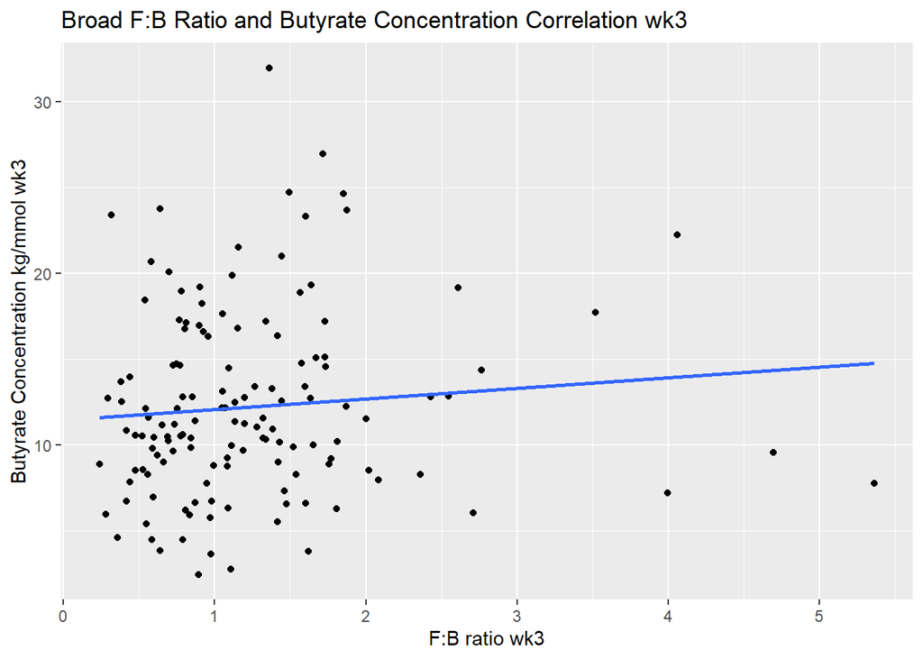

```r
lm_wk3_but_Broad_plot<-BMI_phylum_scfa %>%
  ggplot(aes(x = fb_ratio_wk3,
             y = but_wk3)) +
  geom_point() + #puts data points to match x and y coordinates
  geom_smooth(method = "lm", #used to create a linear best fit line
              se = FALSE) + #hides confidence interval around line
  xlab("F:B ratio wk3") +
  ylab("Butyrate Concentration kg/mmol wk3")  + labs(title = "Broad F:B Ratio and Butyrate Concentration Correlation wk3")
print(lm_wk3_but_Broad_plot)
```

```r
lm_wk3_but_Broad<-BMI_phylum_scfa %>%
  lm(fb_ratio_wk3 ~ but_wk3, data = .) #test relationship
summary(lm_wk3_but_Broad)
```

```
##
## Call:
## lm(formula = fb_ratio_wk3 ~ but_wk3, data = .)
##
## Residuals:
##     Min      1Q  Median      3Q     Max
## -1.0730 -0.5200 -0.1801  0.2977  4.1839
##
## Coefficients:
##             Estimate Std. Error t value Pr(>|t|)
## (Intercept)  1.07089    0.16967   6.311 3.58e-09 ***
## but_wk3      0.01359    0.01269   1.071    0.286
## ---
## Signif. codes:  0 '***' 0.001 '**' 0.01 '*' 0.05 '.' 0.1 ' ' 1
##
## Residual standard error: 0.8128 on 137 degrees of freedom
## Multiple R-squared:  0.008309,   Adjusted R-squared:  0.00107
## F-statistic: 1.148 on 1 and 137 DF,  p-value: 0.2859
```

```r
save_plot(filename = "figures/lm_wk1_but_Broad_plot.pdf",
          plot = lm_wk1_but_Broad_plot,
          nrow = 1, ncol = 1,
          base_aspect_ratio = 2.2)

save_plot(filename = "figures/lm_wk3_but_Broad_plot.pdf",
          plot = lm_wk3_but_Broad_plot,
          nrow = 1, ncol = 1,
          base_aspect_ratio = 2.2)
```

The week 3 F - B ratio and week 3 Butyrate concentration of all the participants has a insignifcant p-value and R^2 value at p=.29 and R^2 = 0.0011 respectively. This also represents no significant correlation.

###F:B and Propionate

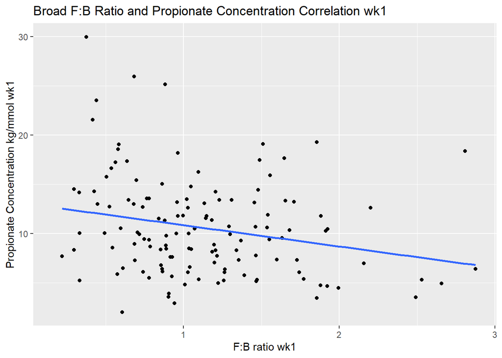

```r
lm_wk1_pro_Broad_plot<-BMI_phylum_scfa %>%
  ggplot(aes(x = fb_ratio_wk1,
             y = pro_wk1)) +
  geom_point() + #puts data points to match x and y coordinates
  geom_smooth(method = "lm", #used to create a linear best fit line
              se = FALSE) + #hides confidence interval around line
  xlab("F:B ratio wk1") +
  ylab("Propionate Concentration kg/mmol wk1")  + labs(title = "Broad F:B Ratio and Propionate Concentration Correlation wk1")
print(lm_wk1_pro_Broad_plot)
```

```r
lm_wk1_pro_Broad<-BMI_phylum_scfa %>%
  lm(fb_ratio_wk1 ~ pro_wk1, data = .) #test relationship
summary(lm_wk1_pro_Broad)
```

```
##
## Call:
## lm(formula = fb_ratio_wk1 ~ pro_wk1, data = .)
##
## Residuals:
##      Min       1Q   Median       3Q      Max
## -0.97952 -0.37792 -0.09592  0.26827  1.88128
##
## Coefficients:
##              Estimate Std. Error t value Pr(>|t|)
## (Intercept)  1.394523   0.107700   12.95  < 2e-16 ***
## pro_wk1     -0.025437   0.009216   -2.76  0.00661 **
## ---
## Signif. codes:  0 '***' 0.001 '**' 0.01 '*' 0.05 '.' 0.1 ' ' 1
##
## Residual standard error: 0.5282 on 131 degrees of freedom
##   (6 observations deleted due to missingness)
## Multiple R-squared:  0.05496,    Adjusted R-squared:  0.04774
## F-statistic: 7.618 on 1 and 131 DF,  p-value: 0.006607
```

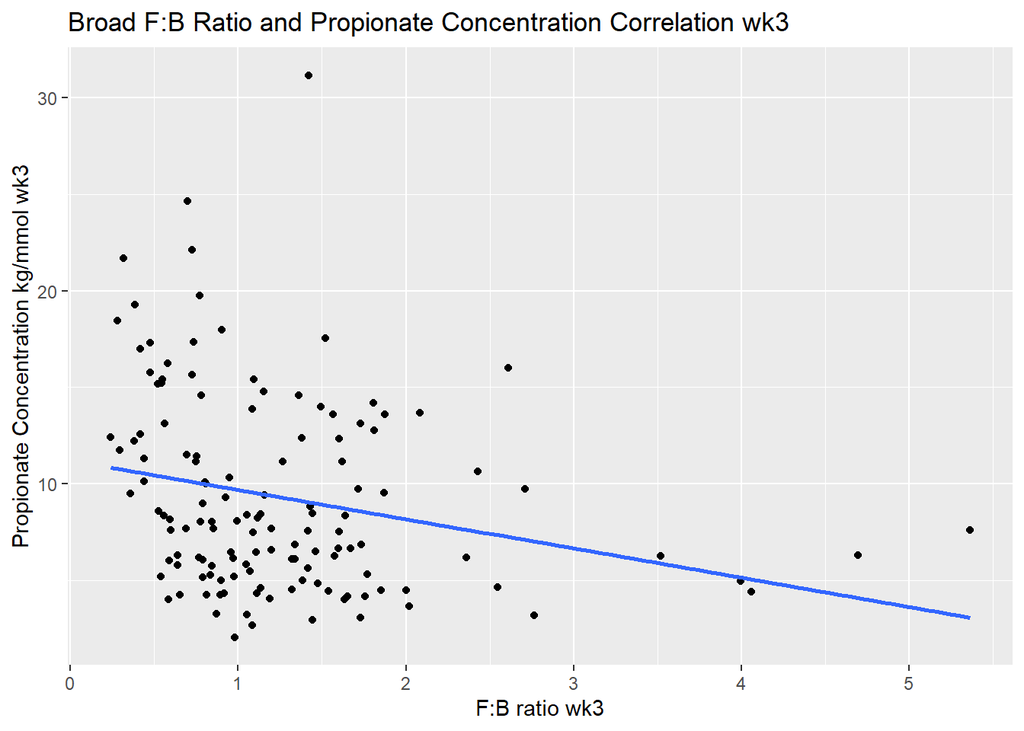

```r
lm_wk3_pro_Broad_plot<-BMI_phylum_scfa %>%
  ggplot(aes(x = fb_ratio_wk3,
             y = pro_wk3))+
  geom_point() + #puts data points to match x and y coordinates
  geom_smooth(method = "lm", #used to create a linear best fit line
              se = FALSE) + #hides confidence interval around line
  xlab("F:B ratio wk3") +
  ylab("Propionate Concentration kg/mmol wk3")  + labs(title = "Broad F:B Ratio and Propionate Concentration Correlation wk3")
print(lm_wk3_pro_Broad_plot)
```

```r
lm_wk3_pro_Broad<-BMI_phylum_scfa %>%
  lm(fb_ratio_wk3 ~ pro_wk3, data = .) #test relationship
summary(lm_wk3_pro_Broad)
```

```
##
## Call:
## lm(formula = fb_ratio_wk3 ~ pro_wk3, data = .)
##
## Residuals:
##     Min      1Q  Median      3Q     Max
## -0.8853 -0.5050 -0.2312  0.2681  4.0435
##
## Coefficients:
##             Estimate Std. Error t value Pr(>|t|)
## (Intercept)  1.61489    0.14364  11.243  < 2e-16 ***
## pro_wk3     -0.03942    0.01356  -2.908  0.00426 **
## ---
## Signif. codes:  0 '***' 0.001 '**' 0.01 '*' 0.05 '.' 0.1 ' ' 1
##
## Residual standard error: 0.7994 on 133 degrees of freedom
##   (4 observations deleted due to missingness)
## Multiple R-squared:  0.05978,    Adjusted R-squared:  0.05271
## F-statistic: 8.457 on 1 and 133 DF,  p-value: 0.004263
```

```r
save_plot(filename = "figures/lm_wk1_pro_Broad_plot.pdf",
          plot = lm_wk1_pro_Broad_plot,
          nrow = 1, ncol = 1,
          base_aspect_ratio = 2.1)
save_plot(filename = "figures/lm_wk3_pro_Broad_plot.pdf",
          plot = lm_wk3_pro_Broad_plot,
          nrow = 1, ncol = 1,
          base_aspect_ratio = 2.1)
```

Similarly, The week 3 F - B ratio and week 3 Propionate concentration of all the participants has a signifcant p-value and insignificant R^2 value at p=.0043 and R^2 = .053 respectively. This also represents no significant correlation.

##Underweight ###F:B and BMI

```r
lm_under_BMI_wk1<-underweight_phylum_scfa %>%
  lm(fb_ratio_wk1 ~ BMI, data = .) #test relationship
summary(lm_under_BMI_wk1)
```

```
##
## Call:
## lm(formula = fb_ratio_wk1 ~ BMI, data = .)
##
## Residuals:
##      Min       1Q   Median       3Q      Max
## -0.57151 -0.27914 -0.09574  0.19793  0.92787
##
## Coefficients:
##             Estimate Std. Error t value Pr(>|t|)
## (Intercept)   2.7263     3.8631   0.706    0.503
## BMI          -0.1028     0.2196  -0.468    0.654
##
## Residual standard error: 0.5116 on 7 degrees of freedom
## Multiple R-squared:  0.03036,    Adjusted R-squared:  -0.1082
## F-statistic: 0.2192 on 1 and 7 DF,  p-value: 0.6539
```

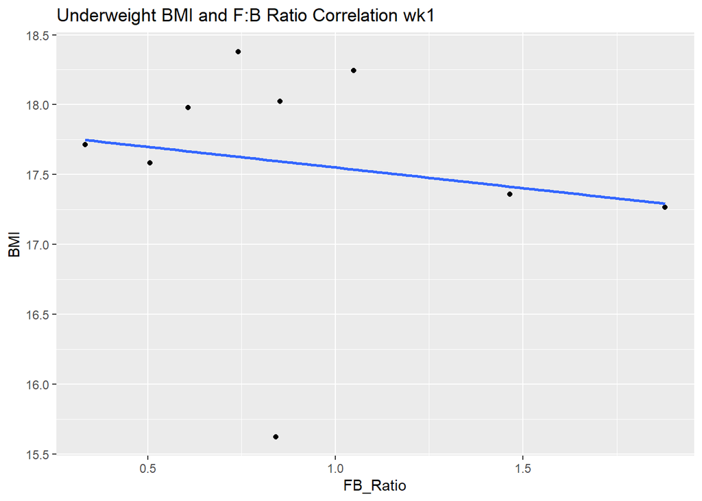

```r
#p-value = 0.6539
#R-squared = -0.1082

lm_under_BMI_plot_wk1<-underweight_phylum_scfa %>%
  ggplot(aes(x = fb_ratio_wk1,
             y = BMI)) +
  geom_point() + #puts data points to match x and y coordinates
  geom_smooth(method = "lm", #used to create a linear best fit line
              se = FALSE) + #hides confidence interval around line
  xlab("FB_Ratio") +
  ylab("BMI")  + labs(title = "Underweight BMI and F:B Ratio Correlation wk1")
print(lm_under_BMI_plot_wk1)
```

```r
save_plot(filename = "figures/lm_under_BMI_plot_wk1.pdf",
          plot = lm_under_BMI_plot_wk1,
          nrow = 1, ncol = 1,
          base_aspect_ratio = 2.1)
```

The p-value for the linear correlation of the week 1 firmicutes to bacteroidetes ratio and the BMI of “underweight” participants was 0.6539, which is not statistically significant. Furthermore, the R value was extremely low (-0.1082), and therefore insignificant. There does not appear to be a statistically significant linear relationship between the week 1 firmicutes to bacteroidetes ratio and BMI among participants whose BMI falls within the CDC’s “underweight” category.

###F:B and Butyrate

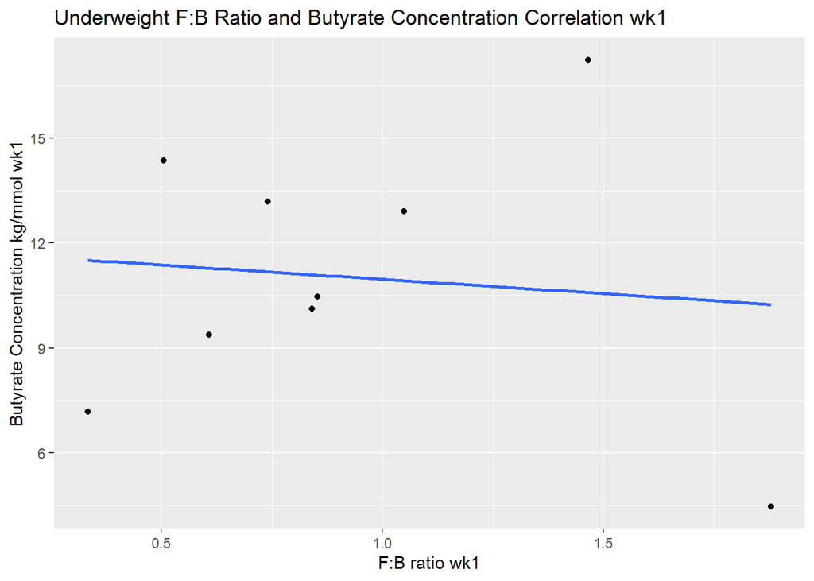

```r
lm_wk1_but_under_plot<-underweight_phylum_scfa %>%
  ggplot(aes(x = fb_ratio_wk1,
             y = but_wk1)) +
  geom_point() + #puts data points to match x and y coordinates
  geom_smooth(method = "lm", #used to create a linear best fit line
              se = FALSE) + #hides confidence interval around line
  xlab("F:B ratio wk1") +
  ylab("Butyrate Concentration kg/mmol wk1")  + labs(title = "Underweight F:B Ratio and Butyrate Concentration Correlation wk1")
print(lm_wk1_but_under_plot)
```

```r
lm_wk1_but_under<-underweight_phylum_scfa %>%
  lm(fb_ratio_wk1 ~ but_wk1, data = .) #test relationship
summary(lm_wk1_but_under)
```

```
##
## Call:
## lm(formula = fb_ratio_wk1 ~ but_wk1, data = .)
##
## Residuals:
##      Min       1Q   Median       3Q      Max
## -0.63556 -0.33327 -0.09032  0.15344  0.87472
##
## Coefficients:
##             Estimate Std. Error t value Pr(>|t|)
## (Intercept)  1.06200    0.54926   1.933   0.0944 .
## but_wk1     -0.01292    0.04728  -0.273   0.7924
## ---
## Signif. codes:  0 '***' 0.001 '**' 0.01 '*' 0.05 '.' 0.1 ' ' 1
##
## Residual standard error: 0.5168 on 7 degrees of freedom
## Multiple R-squared:  0.01056,    Adjusted R-squared:  -0.1308
## F-statistic: 0.07474 on 1 and 7 DF,  p-value: 0.7924
```

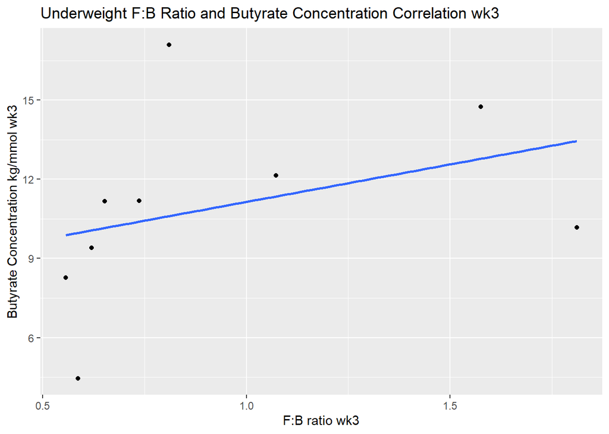

```r
lm_wk3_but_under_plot<-underweight_phylum_scfa %>%
  ggplot(aes(x = fb_ratio_wk3,
             y = but_wk3)) +
  geom_point() + #puts data points to match x and y coordinates
  geom_smooth(method = "lm", #used to create a linear best fit line
              se = FALSE) + #hides confidence interval around line
  xlab("F:B ratio wk3") +
  ylab("Butyrate Concentration kg/mmol wk3")  + labs(title = "Underweight F:B Ratio and Butyrate Concentration Correlation wk3")
print(lm_wk3_but_under_plot)
```

```r
lm_wk3_but_under<-underweight_phylum_scfa %>%
  lm(fb_ratio_wk3 ~ but_wk3, data = .) #test relationship
summary(lm_wk3_but_under)
```

```
##
## Call:
## lm(formula = fb_ratio_wk3 ~ but_wk3, data = .)
##
## Residuals:
##      Min       1Q   Median       3Q      Max
## -0.40413 -0.25710 -0.20974  0.08336  0.91089
##
## Coefficients:
##             Estimate Std. Error t value Pr(>|t|)
## (Intercept)  0.43773    0.51248   0.854    0.421
## but_wk3      0.04543    0.04461   1.018    0.342
##
## Residual standard error: 0.4595 on 7 degrees of freedom
## Multiple R-squared:  0.129,  Adjusted R-squared:  0.004608
## F-statistic: 1.037 on 1 and 7 DF,  p-value: 0.3424
```

```r
save_plot(filename = "figures/lm_wk1_but_under_plot.pdf",
          plot = lm_wk1_but_under_plot,
          nrow = 1, ncol = 1,
          base_aspect_ratio = 2.1)

save_plot(filename = "figures/lm_wk3_but_under_plot.pdf",
          plot = lm_wk3_but_under_plot,
          nrow = 1, ncol = 1,
          base_aspect_ratio = 2.1)
```

The p-value for the linear correlation of the week 1 firmicutes to bacteroidetes ratio and the week 1 Butyrate concentration of the underweight participants is .79, which is not statistically significant. However, the R^2 value is insignificant being very small at R^2=-.1308, which represents too much variation in the data. There is no significant correlation between the week 1 firmicutes - bacteroidetes ratio and Butyrate Concentration.

The week 3 F:B ratio and week 3 Butyrate concentration of the underweight participants has a insignifcant p-value and R^2 value at p=.3424 and R^2 = 0.004608 respectively. This also represents no significant correlation.

###F:B and Propionate

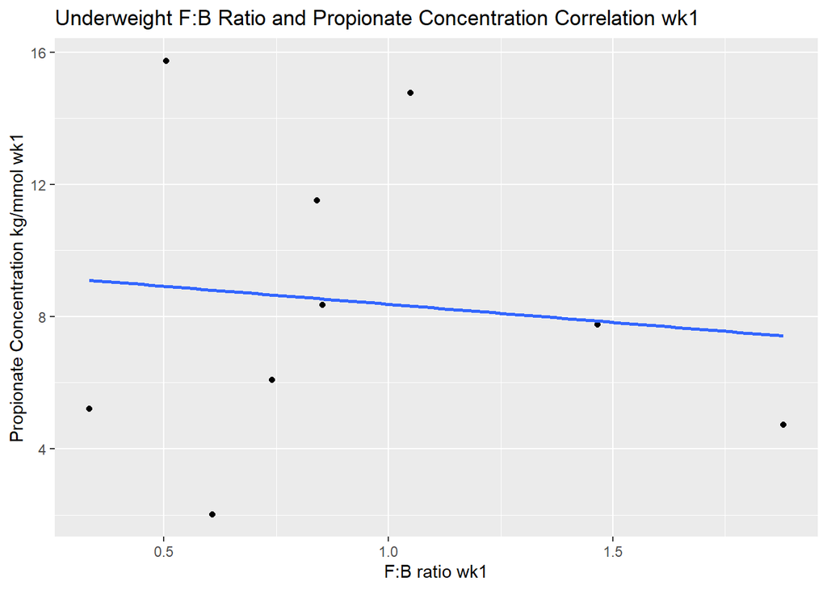

```r
lm_wk1_pro_under_plot<-underweight_phylum_scfa %>%
  ggplot(aes(x = fb_ratio_wk1,
             y = pro_wk1)) +
  geom_point() + #puts data points to match x and y coordinates
  geom_smooth(method = "lm", #used to create a linear best fit line
              se = FALSE) + #hides confidence interval around line
   xlab("F:B ratio wk1") +
  ylab("Propionate Concentration kg/mmol wk1")  + labs(title = "Underweight F:B Ratio and Propionate Concentration Correlation wk1")
print(lm_wk1_pro_under_plot)
```

```r
lm_wk1_pro_under<-underweight_phylum_scfa %>%
  lm(fb_ratio_wk1 ~ pro_wk1, data = .) #test relationship
summary(lm_wk1_pro_under)
```

```
##
## Call:
## lm(formula = fb_ratio_wk1 ~ pro_wk1, data = .)
##
## Residuals:
##      Min       1Q   Median       3Q      Max
## -0.62432 -0.32751 -0.06757  0.20391  0.91518
##
## Coefficients:
##             Estimate Std. Error t value Pr(>|t|)
## (Intercept)  1.01969    0.37301   2.734   0.0292 *
## pro_wk1     -0.01185    0.03910  -0.303   0.7707
## ---
## Signif. codes:  0 '***' 0.001 '**' 0.01 '*' 0.05 '.' 0.1 ' ' 1
##
## Residual standard error: 0.5162 on 7 degrees of freedom
## Multiple R-squared:  0.01295,    Adjusted R-squared:  -0.1281
## F-statistic: 0.09181 on 1 and 7 DF,  p-value: 0.7707
```

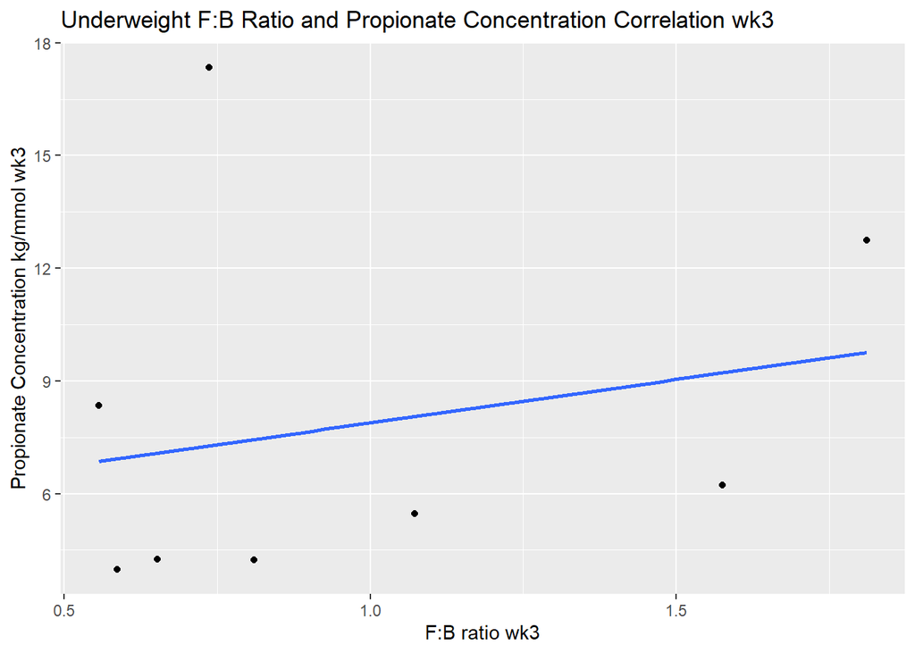

```r
lm_wk3_pro_under_plot<-underweight_phylum_scfa %>%
  ggplot(aes(x = fb_ratio_wk3,
             y = pro_wk3)) +
  geom_point() + #puts data points to match x and y coordinates
  geom_smooth(method = "lm", #used to create a linear best fit line
              se = FALSE) + #hides confidence interval around line
 xlab("F:B ratio wk3") +
  ylab("Propionate Concentration kg/mmol wk3")  + labs(title = "Underweight F:B Ratio and Propionate Concentration Correlation wk3")
print(lm_wk3_pro_under_plot)
```

```r
lm_wk3_pro_under<-underweight_phylum_scfa %>%
  lm(fb_ratio_wk3 ~ pro_wk3, data = .) #test relationship
summary(lm_wk3_pro_under)
```

```
##
## Call:
## lm(formula = fb_ratio_wk3 ~ pro_wk3, data = .)
##
## Residuals:
##     Min      1Q  Median      3Q     Max
## -0.4521 -0.3348 -0.1638  0.2721  0.7259
##
## Coefficients:
##             Estimate Std. Error t value Pr(>|t|)
## (Intercept)  0.80012    0.35362   2.263   0.0643 .
## pro_wk3      0.02238    0.03912   0.572   0.5880
## ---
## Signif. codes:  0 '***' 0.001 '**' 0.01 '*' 0.05 '.' 0.1 ' ' 1
##
## Residual standard error: 0.5005 on 6 degrees of freedom
##   (1 observation deleted due to missingness)
## Multiple R-squared:  0.05172,    Adjusted R-squared:  -0.1063
## F-statistic: 0.3273 on 1 and 6 DF,  p-value: 0.588
```

```r
save_plot(filename = "figures/lm_wk1_pro_under_plot.pdf",
          plot = lm_wk1_pro_under_plot,
          nrow = 1, ncol = 1,
          base_aspect_ratio = 2.1)

save_plot(filename = "figures/lm_wk3_pro_under_plot.pdf",
          plot = lm_wk3_pro_under_plot,
          nrow = 1, ncol = 1,
          base_aspect_ratio = 2.1)
```

##Healthy Weight ###Wk1 F:B and BMI

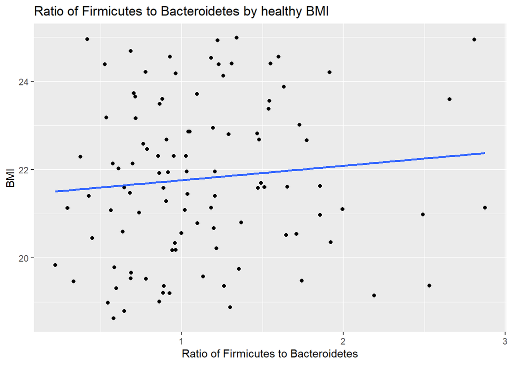

```r
#PLOT
hwk1fb_BMI_plot<-healthy_phylum_scfa %>%
  ggplot(aes(x = fb_ratio_wk1,
             y = BMI)) +
  geom_point() + #puts data points to match x and y coordinates
  geom_smooth(method = "lm", #used to create a linear best fit line
              se = FALSE) + #hides confidence interval around line
 labs(title = "Ratio of Firmicutes to Bacteroidetes by healthy BMI",
         x = "Ratio of Firmicutes to Bacteroidetes",
         y = "BMI")
print(hwk1fb_BMI_plot)
```

```r
#TEST
hwk1fb_BMI_test <- healthy_phylum_scfa %>%
  lm(fb_ratio_wk1 ~ BMI, data = .) #test relationship
summary(hwk1fb_BMI_test) #view results
```

```
##
## Call:
## lm(formula = fb_ratio_wk1 ~ BMI, data = .)
##
## Residuals:
##     Min      1Q  Median      3Q     Max
## -0.8493 -0.3908 -0.1168  0.3073  1.7647
##
## Coefficients:
##             Estimate Std. Error t value Pr(>|t|)
## (Intercept)  0.45952    0.65672   0.700    0.486
## BMI          0.03073    0.03002   1.024    0.308
##
## Residual standard error: 0.5471 on 103 degrees of freedom
## Multiple R-squared:  0.01008,    Adjusted R-squared:  0.000465
## F-statistic: 1.048 on 1 and 103 DF,  p-value: 0.3083
```

```r
#p-value = 0.3083
#Adjusted R-squared = 0.000465

#Save Plot
save_plot(filename = "figures/hwk1fb_BMI_plot.pdf",
          plot = hwk1fb_BMI_plot,
          nrow = 1, ncol = 1,
          base_aspect_ratio = 2.1)
```

The p-value for the linear correlation of the week 1 firmicutes to bacteroidetes ratio and the BMI of “healthy” participants was 0.3083, which is not statistically significant. Furthermore, the R value was an insignificant value close to zero (0.000465). There does not appear to be a statistically significant linear relationship between the week 1 firmicutes to bacteroidetes ratio and BMI among participants whose BMI falls within the CDC’s “Healthy” category.

###Wk1 F:B and Wk1 Butyrate

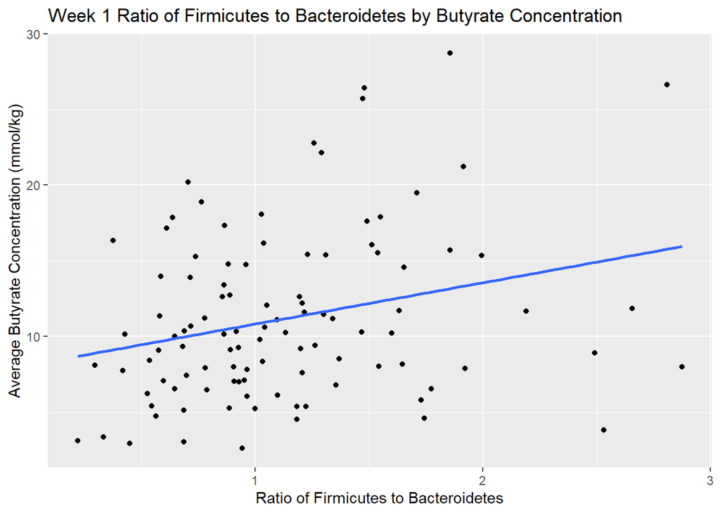

```r
#PLOT
hwk1fb_wk1but_plot<-healthy_phylum_scfa %>%
  ggplot(aes(x = fb_ratio_wk1,
             y = but_wk1)) +
  geom_point() + #puts data points to match x and y coordinates
  geom_smooth(method = "lm", #used to create a linear best fit line
              se = FALSE) + #hides confidence interval around line
 labs(title = "Week 1 Ratio of Firmicutes to Bacteroidetes by Butyrate Concentration",
         x = "Ratio of Firmicutes to Bacteroidetes",
         y = "Average Butyrate Concentration (mmol/kg)")
print(hwk1fb_wk1but_plot)
```

```r
#TEST
hwk1fb_wk1but_test <- healthy_phylum_scfa %>%
  lm(fb_ratio_wk1 ~ but_wk1, data = .) #test relationship
summary(hwk1fb_wk1but_test) #view results
```

```
##
## Call:
## lm(formula = fb_ratio_wk1 ~ but_wk1, data = .)
##
## Residuals:
##      Min       1Q   Median       3Q      Max
## -0.89047 -0.36217 -0.07759  0.24425  1.82806
##
## Coefficients:
##             Estimate Std. Error t value Pr(>|t|)
## (Intercept) 0.834786   0.116413   7.171 1.17e-10 ***
## but_wk1     0.026389   0.009333   2.828  0.00564 **
## ---
## Signif. codes:  0 '***' 0.001 '**' 0.01 '*' 0.05 '.' 0.1 ' ' 1
##
## Residual standard error: 0.5297 on 103 degrees of freedom
## Multiple R-squared:  0.07203,    Adjusted R-squared:  0.06302
## F-statistic: 7.995 on 1 and 103 DF,  p-value: 0.005637
```

```r
#p-value = 0.005637
#Adjusted R-squared = 0.06302

#Save Plot
save_plot(filename = "figures/hwk1fb_wk1but_plot.pdf",
          plot = hwk1fb_wk1but_plot,
          nrow = 1, ncol = 1,
          base_aspect_ratio = 2.1)
```

The p-value for the linear correlation of the week 1 firmicutes to bacteroidetes ratio and the week 1 average butyrate concentration among “healthy” participants was 0.005637, which falls within a 95% confidence interval. However, the R value was an insignificant value close to zero (0.06302). There does not appear to be a statistically significant linear relationship between the week 1 firmicutes to bacteroidetes ratio and the week 1 average butyrate concentration among participants whose BMI falls within the CDC’s “Healthy” category.

###Wk1 F:B and Wk1 Propionate

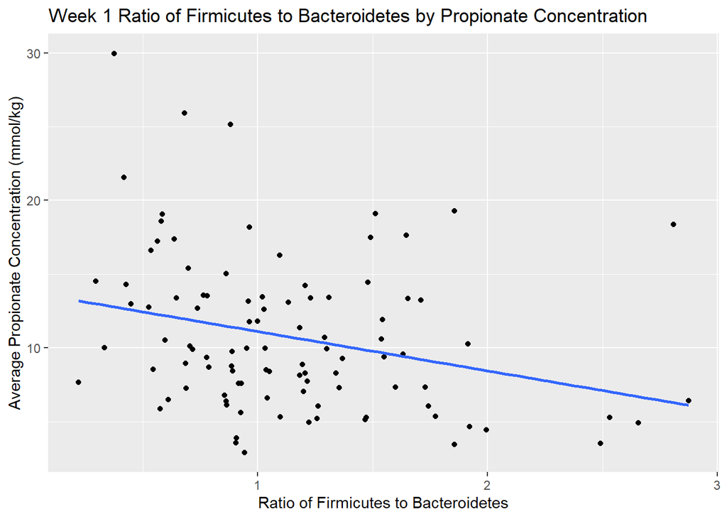

```r
#PLOT
hwk1fb_wk1pro_plot<-healthy_phylum_scfa %>%
  ggplot(aes(x = fb_ratio_wk1,
             y = pro_wk1)) +
  geom_point() + #puts data points to match x and y coordinates
  geom_smooth(method = "lm", #used to create a linear best fit line
              se = FALSE) + #hides confidence interval around line
 labs(title = "Week 1 Ratio of Firmicutes to Bacteroidetes by Propionate Concentration",
         x = "Ratio of Firmicutes to Bacteroidetes",
         y = "Average Propionate Concentration (mmol/kg)")
print(hwk1fb_wk1pro_plot)
```

```r
#TEST
hwk1fb_wk1pro_test <- healthy_phylum_scfa %>%
  lm(fb_ratio_wk1 ~ pro_wk1, data = .) #test relationship
summary(hwk1fb_wk1pro_test) #view results
```

```
##
## Call:
## lm(formula = fb_ratio_wk1 ~ pro_wk1, data = .)
##
## Residuals:
##     Min      1Q  Median      3Q     Max
## -1.0026 -0.3938 -0.1033  0.1928  1.8976
##
## Coefficients:
##             Estimate Std. Error t value Pr(>|t|)
## (Intercept)  1.44580    0.12032  12.017  < 2e-16 ***
## pro_wk1     -0.02912    0.01008  -2.889  0.00475 **
## ---
## Signif. codes:  0 '***' 0.001 '**' 0.01 '*' 0.05 '.' 0.1 ' ' 1
##
## Residual standard error: 0.5235 on 99 degrees of freedom
##   (4 observations deleted due to missingness)
## Multiple R-squared:  0.07773,    Adjusted R-squared:  0.06841
## F-statistic: 8.344 on 1 and 99 DF,  p-value: 0.004754
```

```r
#p-value = 0.004754
#Adjusted R-squared = 0.06841

#Save Plot
save_plot(filename = "figures/hwk1fb_wk1pro_plot.pdf",
          plot = hwk1fb_wk1pro_plot,
          nrow = 1, ncol = 1,
          base_aspect_ratio = 2.1)
```

The p-value for the linear correlation of the week 1 firmicutes to bacteroidetes ratio and the week 1 average propionate concentration among “healthy” participants was 0.004754, which falls within a 95% confidence interval. However, the R value was an insignificant value close to zero (0.06841). There does not appear to be a statistically significant linear relationship between the week 1 firmicutes to bacteroidetes ratio and the week 1 average propionate concentration among participants whose BMI falls within the CDC’s “Healthy” category.

###Wk3 F:B and Wk3 Butyrate

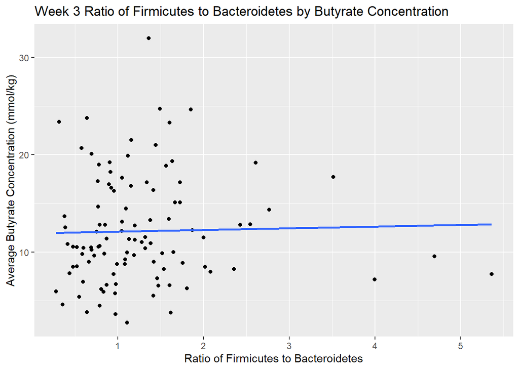

```r
#PLOT
hwk3fb_wk3but_plot<-healthy_phylum_scfa %>%
  ggplot(aes(x = fb_ratio_wk3,
             y = but_wk3)) +
  geom_point() + #puts data points to match x and y coordinates
  geom_smooth(method = "lm", #used to create a linear best fit line
              se = FALSE) + #hides confidence interval around line
 labs(title = "Week 3 Ratio of Firmicutes to Bacteroidetes by Butyrate Concentration",
         x = "Ratio of Firmicutes to Bacteroidetes",
         y = "Average Butyrate Concentration (mmol/kg)")
print(hwk3fb_wk3but_plot)
```

```r
#TEST
hwk3fb_wk3but_test <- healthy_phylum_scfa %>%
  lm(fb_ratio_wk3 ~ but_wk3, data = .) #test relationship
summary(hwk3fb_wk3but_test) #view results
```

```
##
## Call:
## lm(formula = fb_ratio_wk3 ~ but_wk3, data = .)
##
## Residuals:
##     Min      1Q  Median      3Q     Max
## -0.9964 -0.5083 -0.1810  0.2699  4.1076
##
## Coefficients:
##             Estimate Std. Error t value Pr(>|t|)
## (Intercept) 1.222715   0.195979   6.239 9.89e-09 ***
## but_wk3     0.003825   0.014673   0.261    0.795
## ---
## Signif. codes:  0 '***' 0.001 '**' 0.01 '*' 0.05 '.' 0.1 ' ' 1
##
## Residual standard error: 0.8328 on 103 degrees of freedom
## Multiple R-squared:  0.0006594,  Adjusted R-squared:  -0.009043
## F-statistic: 0.06797 on 1 and 103 DF,  p-value: 0.7948
```

```r
#p-value = 0.7948
#Adjusted R-squared = -0.009043

#Save Plot
save_plot(filename = "figures/hwk3fb_wk3but_plot.pdf",
          plot = hwk3fb_wk3but_plot,
          nrow = 1, ncol = 1,
          base_aspect_ratio = 2.1)
```

The p-value for the linear correlation of the week 3 firmicutes to bacteroidetes ratio and the week 3 average butyrate concentration among “healthy” participants was 0.7948, which is not statistically significant. Furthermore, the R value was an insignificant value close to zero (-0.009043). There does not appear to be a statistically significant linear relationship between the week 3 firmicutes to bacteroidetes ratio and the week 3 average butyrate concentration among participants whose BMI falls within the CDC’s “Healthy” category.

###Wk3 F:B and Wk3 Propionate

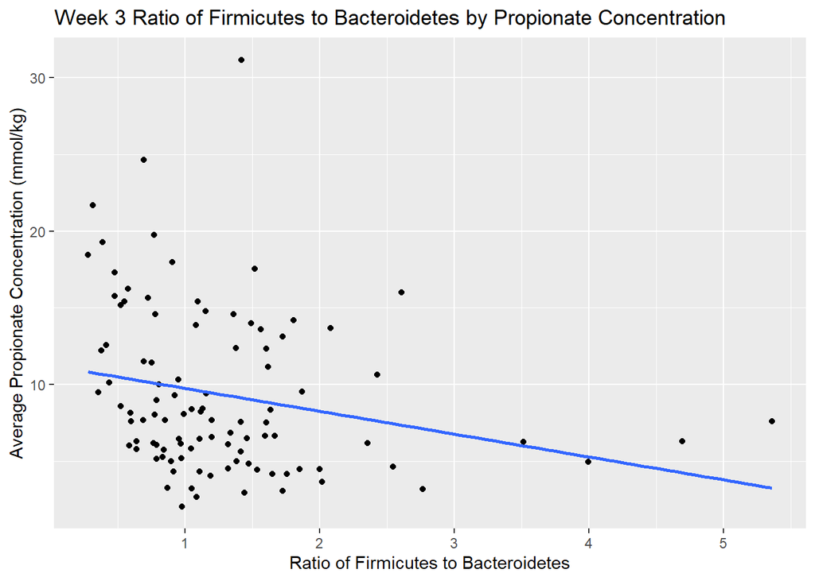

```r
#PLOT
hwk3fb_wk3pro_plot<-healthy_phylum_scfa %>%
  ggplot(aes(x = fb_ratio_wk3,
             y = pro_wk3)) +
  geom_point() + #puts data points to match x and y coordinates
  geom_smooth(method = "lm", #used to create a linear best fit line
              se = FALSE) + #hides confidence interval around line
 labs(title = "Week 3 Ratio of Firmicutes to Bacteroidetes by Propionate Concentration",
         x = "Ratio of Firmicutes to Bacteroidetes",
         y = "Average Propionate Concentration (mmol/kg)")
print(hwk3fb_wk3pro_plot)
```

```r
#TEST
hwk3fb_wk3pro_test <- healthy_phylum_scfa %>%
  lm(fb_ratio_wk3 ~ pro_wk3, data = .) #test relationship
summary(hwk3fb_wk3pro_test) #view results
```

```
##
## Call:
## lm(formula = fb_ratio_wk3 ~ pro_wk3, data = .)
##
## Residuals:
##     Min      1Q  Median      3Q     Max
## -0.9143 -0.5030 -0.1932  0.2727  4.0151
##
## Coefficients:
##             Estimate Std. Error t value Pr(>|t|)
## (Intercept)  1.62858    0.16498   9.871   <2e-16 ***
## pro_wk3     -0.03748    0.01540  -2.433   0.0167 *
## ---
## Signif. codes:  0 '***' 0.001 '**' 0.01 '*' 0.05 '.' 0.1 ' ' 1
##
## Residual standard error: 0.8185 on 100 degrees of freedom
##   (3 observations deleted due to missingness)
## Multiple R-squared:  0.05589,    Adjusted R-squared:  0.04645
## F-statistic:  5.92 on 1 and 100 DF,  p-value: 0.01675
```

```r
#p-value = 0.01675
#Adjusted R-squared = 0.04645

#Save Plot
save_plot(filename = "figures/hwk3fb_wk3pro_plot.pdf",
          plot = hwk3fb_wk3pro_plot,
          nrow = 1, ncol = 1,
          base_aspect_ratio = 2.1)
```

The p-value for the linear correlation of the week 3 firmicutes to bacteroidetes ratio and the week 3 average propionate concentration among “healthy” participants was 0.01675, which falls within a 95% confidence interval. However, the R value was an insignificant value close to zero (0.04645). There does not appear to be a statistically significant linear relationship between the week 3 firmicutes to bacteroidetes ratio and the week 3 average propionate concentration among participants whose BMI falls within the CDC’s “Healthy” category.

##Overweight ##Wk1 F:B and BMI

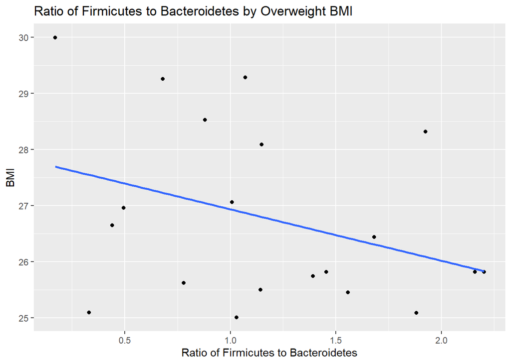

```r
#PLOT
ovwk1fb_BMI_plot<-overweight_phylum_scfa %>%
  ggplot(aes(x = fb_ratio_wk1,
             y = BMI)) +
  geom_point() + #puts data points to match x and y coordinates
  geom_smooth(method = "lm", #used to create a linear best fit line
              se = FALSE) + #hides confidence interval around line
 labs(title = "Ratio of Firmicutes to Bacteroidetes by Overweight BMI",
         x = "Ratio of Firmicutes to Bacteroidetes",
         y = "BMI")
print(ovwk1fb_BMI_plot)
```

```r
#TEST
ovwk1fb_BMI_test <- overweight_phylum_scfa %>%
  lm(fb_ratio_wk1 ~ BMI, data = .) #test relationship
summary(ovwk1fb_BMI_test) #view results
```

```
##
## Call:
## lm(formula = fb_ratio_wk1 ~ BMI, data = .)
##
## Residuals:
##      Min       1Q   Median       3Q      Max
## -1.06352 -0.41901  0.01222  0.29048  0.95898
##
## Coefficients:
##             Estimate Std. Error t value Pr(>|t|)
## (Intercept)  4.73184    2.25636   2.097   0.0504 .
## BMI         -0.13295    0.08412  -1.581   0.1314
## ---
## Signif. codes:  0 '***' 0.001 '**' 0.01 '*' 0.05 '.' 0.1 ' ' 1
##
## Residual standard error: 0.5797 on 18 degrees of freedom
## Multiple R-squared:  0.1219, Adjusted R-squared:  0.07309
## F-statistic: 2.498 on 1 and 18 DF,  p-value: 0.1314
```

```r
#p-value = 0.1314
#Adjusted R-squared = 0.07309

#Save Plot
save_plot(filename = "figures/ovwk1fb_BMI_plot.pdf", plot = ovwk1fb_BMI_plot, nrow = 1, ncol = 1, base_aspect_ratio = 2:1)
```

The p-value for the linear correlation of the week 1 firmicutes to bacteroidetes ratio and the BMI of “overweight” participants was 0.1314, which is not statistically significant. Furthermore, the R value was an insignificant value close to zero (0.07309). There does not appear to be a statistically significant linear relationship between the week 1 firmicutes to bacteroidetes ratio and BMI among participants whose BMI falls within the CDC’s “Overweight” category.

###Wk1 F:B and Wk1 Butyrate

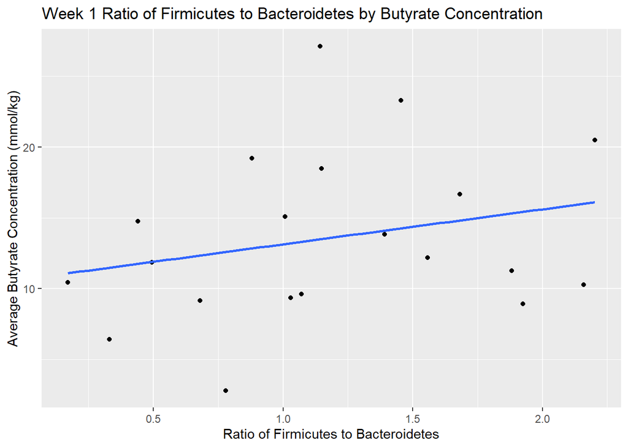

```r
#PLOT
ovwk1fb_wk1but_plot<-overweight_phylum_scfa %>%
  ggplot(aes(x = fb_ratio_wk1,
             y = but_wk1)) +
  geom_point() + #puts data points to match x and y coordinates
  geom_smooth(method = "lm", #used to create a linear best fit line
              se = FALSE) + #hides confidence interval around line
 labs(title = "Week 1 Ratio of Firmicutes to Bacteroidetes by Butyrate Concentration",
         x = "Ratio of Firmicutes to Bacteroidetes",
         y = "Average Butyrate Concentration (mmol/kg)")
print(ovwk1fb_wk1but_plot)
```

```r
#TEST
ovwk1fb_wk1but_test <- overweight_phylum_scfa %>%
  lm(fb_ratio_wk1 ~ but_wk1, data = .) #test relationship
summary(ovwk1fb_wk1but_test) #view results
```

```
##
## Call:
## lm(formula = fb_ratio_wk1 ~ but_wk1, data = .)
##
## Residuals:
##      Min       1Q   Median       3Q      Max
## -0.92175 -0.39333 -0.07635  0.42356  1.07132
##
## Coefficients:
##             Estimate Std. Error t value Pr(>|t|)
## (Intercept)  0.82642    0.34136   2.421   0.0263 *
## but_wk1      0.02545    0.02316   1.099   0.2863
## ---
## Signif. codes:  0 '***' 0.001 '**' 0.01 '*' 0.05 '.' 0.1 ' ' 1
##
## Residual standard error: 0.5989 on 18 degrees of freedom
## Multiple R-squared:  0.06286,    Adjusted R-squared:  0.0108
## F-statistic: 1.207 on 1 and 18 DF,  p-value: 0.2863
```

```r
#p-value = 0.2863
#Adjusted R-squared = 0.0108

#Save Plot
save_plot(filename = "figures/ovwk1fb_wk1but_plot.pdf", plot = ovwk1fb_wk1but_plot, nrow = 1, ncol = 1, base_aspect_ratio = 2:1)
```

###Wk1 F:B and Wk1 Propionate

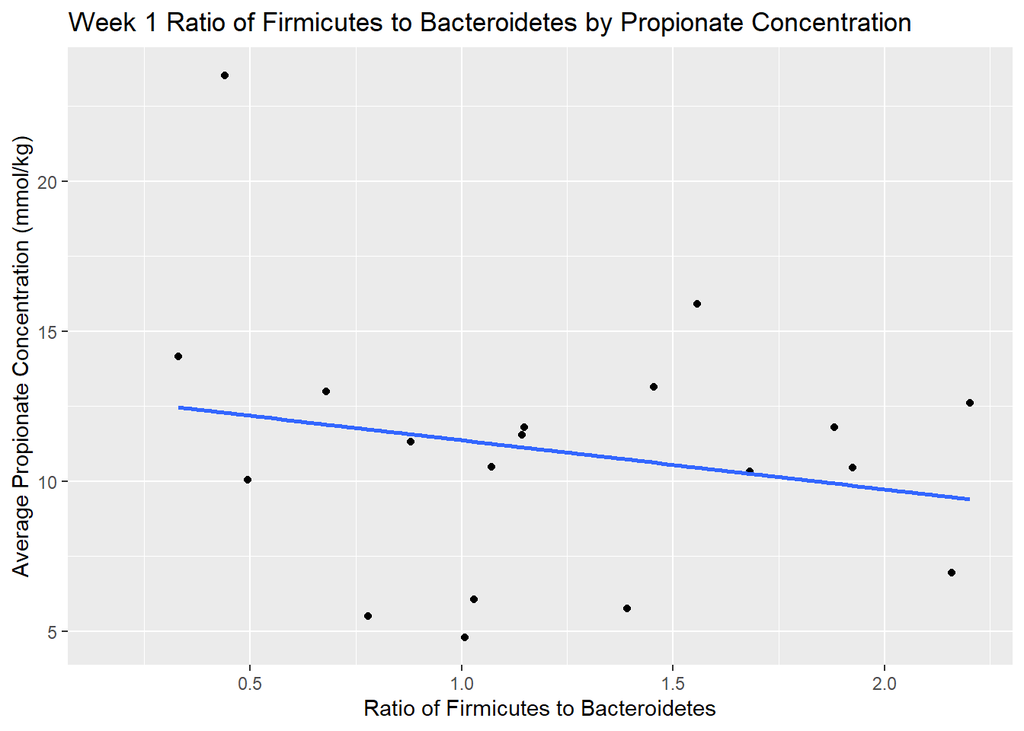

```r
#PLOT
ovwk1fb_wk1pro_plot<-overweight_phylum_scfa %>%
  ggplot(aes(x = fb_ratio_wk1,
             y = pro_wk1)) +
  geom_point() + #puts data points to match x and y coordinates
  geom_smooth(method = "lm", #used to create a linear best fit line
              se = FALSE) + #hides confidence interval around line
 labs(title = "Week 1 Ratio of Firmicutes to Bacteroidetes by Propionate Concentration",
         x = "Ratio of Firmicutes to Bacteroidetes",
         y = "Average Propionate Concentration (mmol/kg)")
print(ovwk1fb_wk1pro_plot)
```

```r
#TEST
ovwk1fb_wk1pro_test <- overweight_phylum_scfa %>%
  lm(fb_ratio_wk1 ~ pro_wk1, data = .) #test relationship
summary(ovwk1fb_wk1pro_test) #view results
```

```
##
## Call:
## lm(formula = fb_ratio_wk1 ~ pro_wk1, data = .)
##
## Residuals:
##      Min       1Q   Median       3Q      Max
## -0.80543 -0.41150 -0.06605  0.45390  1.02211
##
## Coefficients:
##             Estimate Std. Error t value Pr(>|t|)
## (Intercept)  1.53069    0.36471   4.197 0.000605 ***
## pro_wk1     -0.02785    0.03092  -0.901 0.380231
## ---
## Signif. codes:  0 '***' 0.001 '**' 0.01 '*' 0.05 '.' 0.1 ' ' 1
##
## Residual standard error: 0.5723 on 17 degrees of freedom
##   (1 observation deleted due to missingness)
## Multiple R-squared:  0.04557,    Adjusted R-squared:  -0.01058
## F-statistic: 0.8116 on 1 and 17 DF,  p-value: 0.3802
```

```r
#p-value = 0.3802
#Adjusted R-squared = -0.01058

#Save Plot
save_plot(filename = "figures/ovwk1fb_wk1pro_plot.pdf", plot = ovwk1fb_wk1pro_plot, nrow = 1, ncol = 1, base_aspect_ratio = 2:1)
```

The p-value for the linear correlation of the week 1 firmicutes to bacteroidetes ratio and the week 1 average propionate concentration among “overweight” participants was 0.3802, which falls within a 95% confidence interval. However, the R value was an insignificant value close to zero (-0.01058). There does not appear to be a statistically significant linear relationship between the week 1 firmicutes to bacteroidetes ratio and the week 1 average propionate concentration among participants whose BMI falls within the CDC’s “Overweight” category.

###Wk3 F:B and Wk3 Butyrate

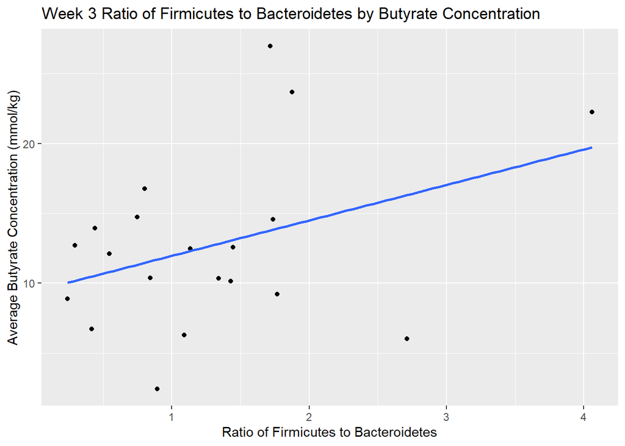

```r
#PLOT
ovwk3fb_wk3but_plot<-overweight_phylum_scfa %>%
  ggplot(aes(x = fb_ratio_wk3,
             y = but_wk3)) +
  geom_point() + #puts data points to match x and y coordinates
  geom_smooth(method = "lm", #used to create a linear best fit line
              se = FALSE) + #hides confidence interval around line
 labs(title = "Week 3 Ratio of Firmicutes to Bacteroidetes by Butyrate Concentration",
         x = "Ratio of Firmicutes to Bacteroidetes",
         y = "Average Butyrate Concentration (mmol/kg)")
print(ovwk3fb_wk3but_plot)
```

```r
#TEST
ovwk3fb_wk3but_test <- overweight_phylum_scfa %>%
  lm(fb_ratio_wk3 ~ but_wk3, data = .) #test relationship
summary(ovwk3fb_wk3but_test) #view results
```

```
##
## Call:
## lm(formula = fb_ratio_wk3 ~ but_wk3, data = .)
##
## Residuals:
##      Min       1Q   Median       3Q      Max
## -0.98589 -0.65940 -0.07489  0.21897  2.24361
##
## Coefficients:
##             Estimate Std. Error t value Pr(>|t|)
## (Intercept)  0.56514    0.45450   1.243    0.230
## but_wk3      0.05615    0.03247   1.729    0.101
##
## Residual standard error: 0.8666 on 18 degrees of freedom
## Multiple R-squared:  0.1425, Adjusted R-squared:  0.09483
## F-statistic: 2.991 on 1 and 18 DF,  p-value: 0.1009
```

```r
#p-value = 0.1009
#Adjusted R-squared = 0.09483

#Save Plot
save_plot(filename = "figures/ovwk3fb_wk3but_plot.pdf", plot = ovwk3fb_wk3but_plot, nrow = 1, ncol = 1, base_aspect_ratio = 2:1)
```

The p-value for the linear correlation of the week 3 firmicutes to bacteroidetes ratio and the week 3 average butyrate concentration among “overweight” participants was 0.1009, which is not statistically significant. Furthermore, the R value was an insignificant value close to zero (0.09483). There does not appear to be a statistically significant linear relationship between the week 3 firmicutes to bacteroidetes ratio and the week 3 average butyrate concentration among participants whose BMI falls within the CDC’s “Overweight” category.